# Practical Machine Learning Course Project

Calli

May 10, 2016

#### Summary:

Call caret library

```r
library(caret)
```

Set working directory

```r
getwd()
```

```
## [1] "C:/Users/Calli6/Desktop/Machine Learning"
```

```r
setwd("C:/Users/Calli6/Desktop")
```

#### Preprocessing

Read in training dataset and test dataset

```r
pml.training <- read.csv("C:/Users/Calli6/Desktop/pml-training.csv", stringsAsFactors=FALSE)
pml.testing <- read.csv("C:/Users/Calli6/Desktop/pml-testing.csv", stringsAsFactors = FALSE)
```

There are several empty columns in the test dataset. These columns will not be useful to predict with the test data set so they will be removed from the training datset. The first 7 columns of the training dataset will also be removed. These variables appear to be ID variables or date variables and will probably not be good predictors of the classe variable.

```r
emptycols <- sapply(pml.testing, function (k) all(is.na(k)))
pml.training_noNAcol <- pml.training[!emptycols]
pml.training_final_all <- pml.training_noNAcol[,c(8:60)]
```

#### Principal Components Analysis

Even by removing the empty variables and the ID variables from training dataset there are still 53 variables. Principal components analysis will be used to reduce the number of variables that the model will use.

```r
pml.training_final <- pml.training_noNAcol[,c(8:59)]
principalcomps <- prcomp(pml.training_final)
summary(principalcomps)
```

```
## Importance of components:
##                             PC1      PC2      PC3      PC4       PC5
## Standard deviation     599.3361 534.1798 471.2424 378.5883 355.91845
## Proportion of Variance   0.2635   0.2093   0.1629   0.1051   0.09292
## Cumulative Proportion    0.2635   0.4728   0.6357   0.7408   0.83370
##                              PC6       PC7      PC8       PC9      PC10
## Standard deviation     254.51818 201.03284 173.5671 158.16406 118.24640
## Proportion of Variance   0.04751   0.02964   0.0221   0.01835   0.01026
## Cumulative Proportion    0.88122   0.91086   0.9330   0.95130   0.96156
##                            PC11     PC12     PC13     PC14     PC15
## Standard deviation     97.11690 89.62909 76.38275 68.47000 62.58078
## Proportion of Variance  0.00692  0.00589  0.00428  0.00344  0.00287
## Cumulative Proportion   0.96848  0.97437  0.97865  0.98209  0.98496
##                            PC16     PC17     PC18     PC19     PC20
## Standard deviation     56.73626 53.23824 49.73110 48.70005 41.92135
## Proportion of Variance  0.00236  0.00208  0.00181  0.00174  0.00129
## Cumulative Proportion   0.98732  0.98940  0.99121  0.99295  0.99424
##                            PC21     PC22    PC23     PC24     PC25    PC26
## Standard deviation     37.62798 35.15274 32.9227 30.69078 25.50548 23.3602
## Proportion of Variance  0.00104  0.00091  0.0008  0.00069  0.00048  0.0004
## Cumulative Proportion   0.99528  0.99619  0.9970  0.99767  0.99815  0.9986
##                            PC27     PC28     PC29     PC30     PC31
## Standard deviation     21.56306 20.75661 17.27913 15.16004 13.98539
## Proportion of Variance  0.00034  0.00032  0.00022  0.00017  0.00014
## Cumulative Proportion   0.99889  0.99921  0.99943  0.99960  0.99974
##                           PC32    PC33    PC34    PC35    PC36    PC37
## Standard deviation     9.92249 7.61896 7.29096 6.67947 6.14144 4.12126
## Proportion of Variance 0.00007 0.00004 0.00004 0.00003 0.00003 0.00001
## Cumulative Proportion  0.99981 0.99985 0.99989 0.99993 0.99995 0.99997
##                           PC38    PC39    PC40  PC41  PC42  PC43   PC44
## Standard deviation     3.75911 3.49816 3.36508 1.957 1.492 1.098 0.4652
## Proportion of Variance 0.00001 0.00001 0.00001 0.000 0.000 0.000 0.0000
## Cumulative Proportion  0.99998 0.99999 0.99999 1.000 1.000 1.000 1.0000
##                          PC45   PC46   PC47  PC48   PC49  PC50   PC51
## Standard deviation     0.3938 0.3601 0.3149 0.241 0.2025 0.186 0.1042
## Proportion of Variance 0.0000 0.0000 0.0000 0.000 0.0000 0.000 0.0000
## Cumulative Proportion  1.0000 1.0000 1.0000 1.000 1.0000 1.000 1.0000
##                           PC52
## Standard deviation     0.03681
## Proportion of Variance 0.00000
## Cumulative Proportion  1.00000
```

Plot the principal components to determine how many components we want to use in the model. The plot begins to flatten out around feature number 6 indicating that 6 features will account for most of the variance in the model.

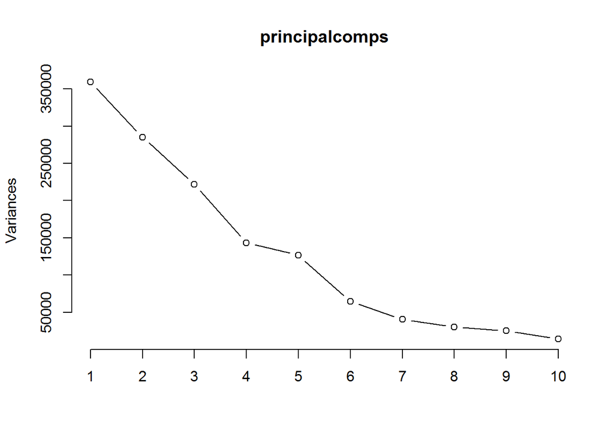

```r
plot(principalcomps, type = "l")
```

From the graph it looks like the first 6 principle components account for most of the variance. We will use 6 principal components for this analysis.

```r
preProc <- preProcess(pml.training_final, method = "pca", pcaComp=6)
preProc
```

```
## Created from 19622 samples and 52 variables
##
## Pre-processing:
##   - centered (52)
##   - ignored (0)
##   - principal component signal extraction (52)
##   - scaled (52)
##
## PCA used 6 components as specified
```

We will use the random forest method to create a model on the training data. The principle components previously calculated will be used.

```r
trainPC <- predict(preProc, pml.training_final)
modelFit <- train(pml.training_final_all$classe~.,method="rf", data= trainPC)
modelFit$finalModel # what are fitted values
```

```
##
## Call:
##  randomForest(x = x, y = y, mtry = param$mtry)
##                Type of random forest: classification
##                      Number of trees: 500
## No. of variables tried at each split: 2
##
##         OOB estimate of  error rate: 8.45%
## Confusion matrix:
##      A    B    C    D    E class.error
## A 5317   62  110   63   28  0.04713262
## B  151 3382  143   67   54  0.10929681
## C   97  111 3053  121   40  0.10783168
## D   72   24  206 2876   38  0.10572139
## E   58   74   63   76 3336  0.07513169
```

```r
confusionMatrix(modelFit)
```

```
## Bootstrapped (25 reps) Confusion Matrix
##
## (entries are percentual average cell counts across resamples)
##
##           Reference
## Prediction    A    B    C    D    E
##          A 26.7  0.9  0.7  0.4  0.4
##          B  0.5 16.6  0.8  0.2  0.5
##          C  0.7  0.8 15.0  1.2  0.4
##          D  0.5  0.5  0.8 14.1  0.5
##          E  0.2  0.4  0.3  0.3 16.7
##
##  Accuracy (average) : 0.8907
```

#### Cross Validation

Because we used a random forest model, cross validation was applied within the model. A random forest model creates a subset of decision trees using different variables. The model then applies a other data to the decision trees and averages all of the outcomes together. This is the cross validation for this model.

#### Validate model with testing dataset

[output not shown]